# CCR Met Data collation and Plots for EDI

Use this file path in Carey Lab Reservoir GitHub Repo: “./Data/DataAlreadyUploadedToEDI/EDIProductionFiles/MakeEML_CCRMetData/2022/”

1. Open the script and check you have the correct function in line 18
2. Change the current start and end times to match the year you are publishing for
3. If there are more than one csv make sure they are all in the Download data chunk. Currently there is only one csv with all of the observations.
4. Once you have made sure everything is up to date press the knit button and it will produce an html file with all of the outputs and plots.

##Check for gaps in the data frame This identifies if there are any daily data gaps in the long-term record

This identifies if there are any sub-daily gaps in the long-term record. Most of these gaps happen when we change the program on the data logger.

```
## [1] "2021-04-09 13:00:00 UTC" "2021-04-09 13:56:00 UTC"
## [1] "2021-07-02 14:00:00 UTC" "2021-07-02 14:41:00 UTC"
## [1] "2022-04-05 12:00:00 UTC" "2022-04-05 13:56:00 UTC"
## [1] "2022-04-20 13:00:00 UTC" "2022-04-20 13:38:00 UTC"
## [1] "2022-04-20 14:00:00 UTC" "2022-04-20 14:53:00 UTC"
## [1] "2022-05-12 10:00:00 UTC" "2022-05-12 10:27:00 UTC"
## [1] "2022-09-29 14:00:00 UTC" "2022-09-29 14:57:00 UTC"
## [1] "2022-09-29 15:00:00 UTC" "2022-09-29 15:18:00 UTC"
## [1] "2023-01-24 16:00:00 UTC" "2023-01-24 16:49:00 UTC"
## [1] "2023-02-28 12:10:00 UTC" "2023-02-28 12:12:00 UTC"
```

## Read in the QAQC File and Check it out

This section reads in the QAQC file and then you can look at the head, tail and structure. Make sure the last row is Dec. 31 23:59 of the publishing year. There should be 45 columns unless a new one has been added.

```r
# read in qaqc function output


ccrmetdata <- read_csv(output_file, col_types = cols(Note_BP_Average_kPa = col_character(), DateTime = col_datetime()))
#fcrmetdata <- read_csv("FCR_Met_final_2015_2022.csv")

# subset file to only unpublished data
ccrmetdata <- ccrmetdata[ccrmetdata$DateTime<ymd_hms(current_time_end),]

# what does the beginning look like
head(ccrmetdata)
```

```
## # A tibble: 6 × 45
##   Reservoir  Site DateTime            Record CR3000Bat…¹ CR300…² PAR_u…³ PAR_T…⁴
##   <chr>     <dbl> <dttm>               <dbl>       <dbl>   <dbl>   <dbl>   <dbl>
## 1 CCR          51 2021-03-29 15:12:00      0        13.2    18.1    288     8.64
## 2 CCR          51 2021-03-29 15:13:00      1        13.0    18.1    287.   17.2
## 3 CCR          51 2021-03-29 15:14:00      2        13.1    18.2    286.   17.2
## 4 CCR          51 2021-03-29 15:15:00      3        13.0    18.3    285.   17.1
## 5 CCR          51 2021-03-29 15:16:00      4        13.0    18.4    284.   17.0
## 6 CCR          51 2021-03-29 15:17:00      5        13.0    18.4    282.   16.9
## # … with 37 more variables: BP_Average_kPa <dbl>, AirTemp_C_Average <dbl>,
## #   RH_percent <dbl>, Rain_Total_mm <dbl>, WindSpeed_Average_m_s <dbl>,
## #   WindDir_degrees <dbl>, ShortwaveRadiationUp_Average_W_m2 <dbl>,
## #   ShortwaveRadiationDown_Average_W_m2 <dbl>,
## #   InfraredRadiationUp_Average_W_m2 <dbl>,
## #   InfraredRadiationDown_Average_W_m2 <dbl>, Albedo_Average_W_m2 <dbl>,
## #   Flag_PAR_umolm2s_Average <dbl>, Note_PAR_umolm2s_Average <chr>, …
```

```r
# Make sure it goes to Dec 31st 23:59 of the previous year or your ending period
tail(ccrmetdata)
```

```
## # A tibble: 6 × 45
##   Reservoir  Site DateTime            Record CR3000Bat…¹ CR300…² PAR_u…³ PAR_T…⁴
##   <chr>     <dbl> <dttm>               <dbl>       <dbl>   <dbl>   <dbl>   <dbl>
## 1 CCR          51 2022-12-31 23:54:00 134436        13.1    11.3      NA      NA
## 2 CCR          51 2022-12-31 23:55:00 134437        13.2    11.3      NA      NA
## 3 CCR          51 2022-12-31 23:56:00 134438        13.2    11.3      NA      NA
## 4 CCR          51 2022-12-31 23:57:00 134439        13.1    11.3      NA      NA
## 5 CCR          51 2022-12-31 23:58:00 134440        13.2    11.3      NA      NA
## 6 CCR          51 2022-12-31 23:59:00 134441        13.2    11.2      NA      NA
## # … with 37 more variables: BP_Average_kPa <dbl>, AirTemp_C_Average <dbl>,
## #   RH_percent <dbl>, Rain_Total_mm <dbl>, WindSpeed_Average_m_s <dbl>,
## #   WindDir_degrees <dbl>, ShortwaveRadiationUp_Average_W_m2 <dbl>,
## #   ShortwaveRadiationDown_Average_W_m2 <dbl>,
## #   InfraredRadiationUp_Average_W_m2 <dbl>,
## #   InfraredRadiationDown_Average_W_m2 <dbl>, Albedo_Average_W_m2 <dbl>,
## #   Flag_PAR_umolm2s_Average <dbl>, Note_PAR_umolm2s_Average <chr>, …
```

```r
# check out the structure
str(ccrmetdata)
```

```
## tibble [924,530 × 45] (S3: tbl_df/tbl/data.frame)
##  $ Reservoir                               : chr [1:924530] "CCR" "CCR" "CCR" "CCR" ...
##  $ Site                                    : num [1:924530] 51 51 51 51 51 51 51 51 51 51 ...
##  $ DateTime                                : POSIXct[1:924530], format: "2021-03-29 15:12:00" "2021-03-29 15:13:00" ...
##  $ Record                                  : num [1:924530] 0 1 2 3 4 5 6 7 8 9 ...
##  $ CR3000Battery_V                         : num [1:924530] 13.2 13.1 13.1 13.1 13.1 ...
##  $ CR3000Panel_Temp_C                      : num [1:924530] 18.1 18.1 18.2 18.3 18.4 ...
##  $ PAR_umolm2s_Average                     : num [1:924530] 288 287 286 285 284 ...
##  $ PAR_Total_mmol_m2                       : num [1:924530] 8.64 17.24 17.16 17.08 17.02 ...
##  $ BP_Average_kPa                          : num [1:924530] NA 98 98 98 98 ...
##  $ AirTemp_C_Average                       : num [1:924530] 14.8 14.7 14.5 14.4 14.3 ...
##  $ RH_percent                              : num [1:924530] 25.8 26.1 28.8 26.6 29.5 ...
##  $ Rain_Total_mm                           : num [1:924530] 0 0 0 0 0 0 0 0 0 0 ...
##  $ WindSpeed_Average_m_s                   : num [1:924530] 0.66 0.629 0.709 0.9 0.75 ...
##  $ WindDir_degrees                         : num [1:924530] 10 29.06 4.407 0.095 35.69 ...
```

[output cut: 31 more lines]

## Check out the Flag requency

Let’s look at the flag Frequency for each variable.

As a reminder here are the flag codes Flag values

0: no flag;

1: value removed due to maintenance and set to NA;

2: sample not collected;

3: negative values set to 0, percent greater than 100 and set to 100, or infinite values set to NA;

4: potentially questionable value and changed or set to NA, see note;

5: questionable value but left in the dataset.

```
## Flag_PAR_umolm2s_Average
##      0      1      2      4   <NA>
## 541720     15 245760 137035      0
## Flag_PAR_Total_mmol_m2
##      0      1      2      4   <NA>
## 543755     15 245759 135001      0
## Flag_BP_Average_kPa
##      0      4   <NA>
## 923405   1125      0
## Flag_AirTemp_C_Average
##      0      1      4   <NA>
## 923630     10    890      0
## Flag_RH_percent
##      0      1      2      3      4   <NA>
## 835608     14  88898      6      4      0
## Flag_Rain_Total_mm
##      0      1      2      4   <NA>
## 844316     40      1  80173      0
## Flag_WindSpeed_Average_m_s
##      0      2      4   <NA>
## 924524      1      5      0
## Flag_WindDir_degrees
##      0      4   <NA>
## 924525      5      0
## Flag_ShortwaveRadiationUp_Average_W_m2
##      0      3      4      5   <NA>
## 473796 450703      4     27      0
## Flag_ShortwaveRadiationDown_Average_W_m2
##      0      1      3      4   <NA>
## 826399     11  98099     21      0
## Flag_InfraredRadiationUp_Average_W_m2
##      0      1      2      4   <NA>
## 924513     11      1      5      0
## Flag_InfraredRadiationDown_Average_W_m2
##      0      1      2      4   <NA>
## 924506     19      1      4      0
## Flag_Albedo_Average_W_m2
##      0      2      3      4   <NA>
## 555651    534 368311     34      0
```

## QAQC Plots

These are QAQC plots to see if there are any questionable values we missed.

### Temperature

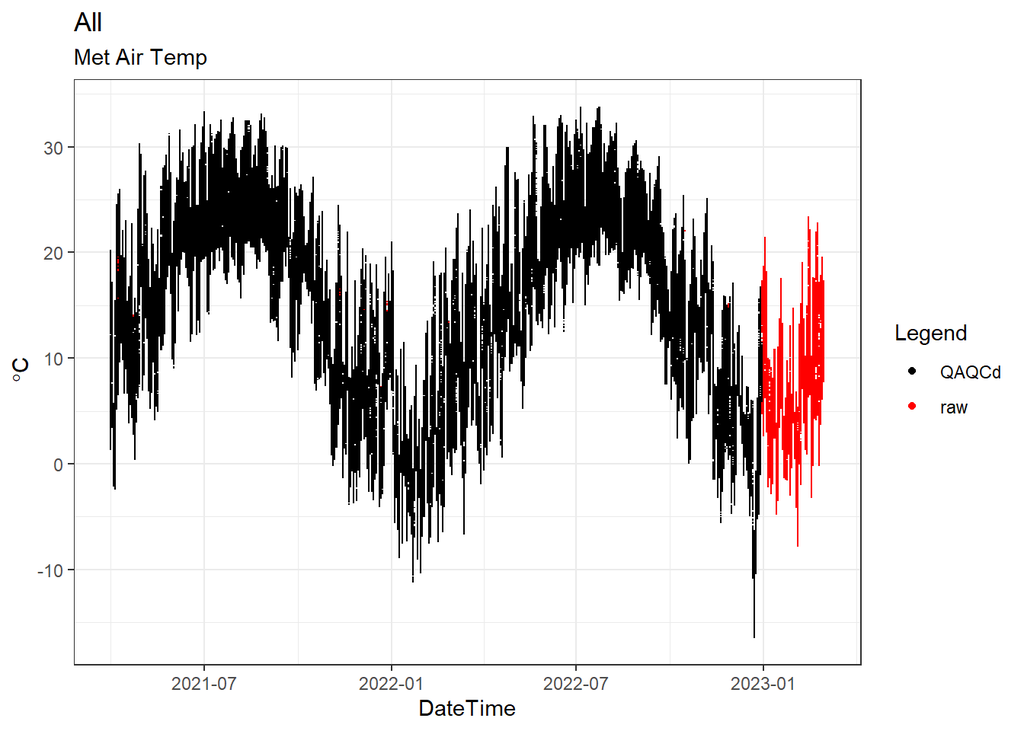

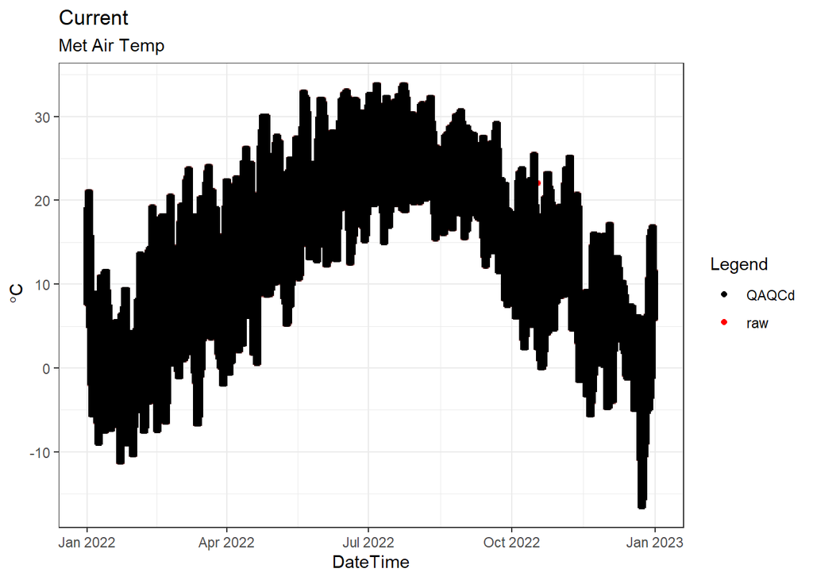

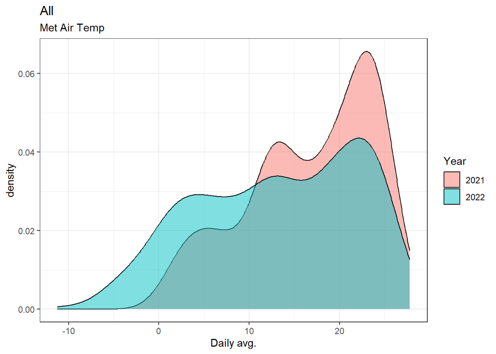

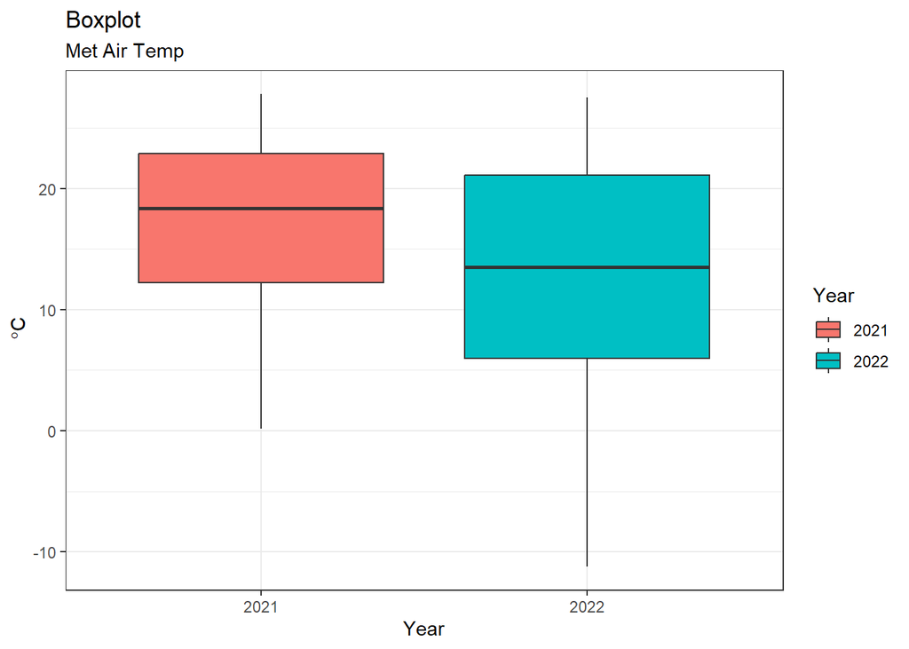

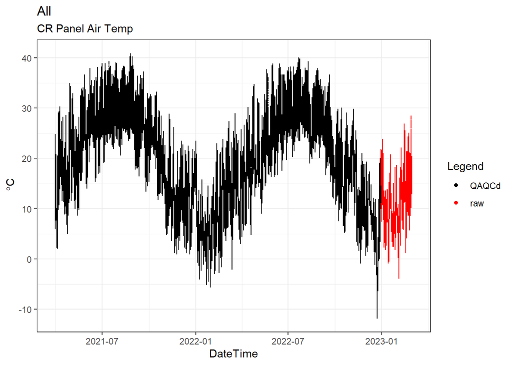

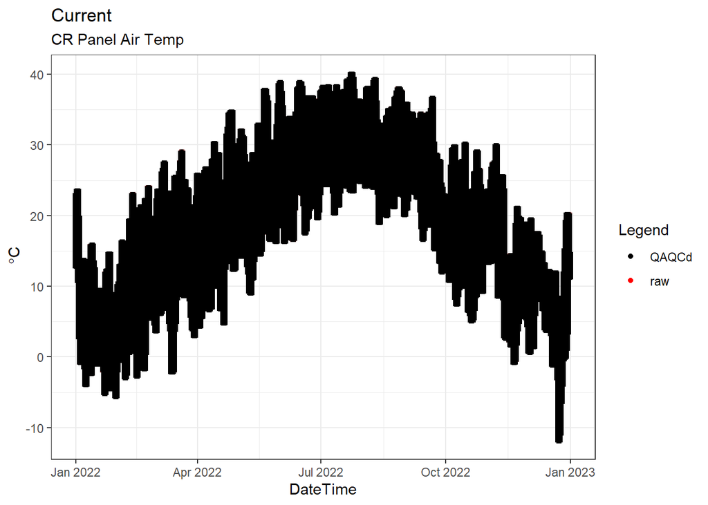

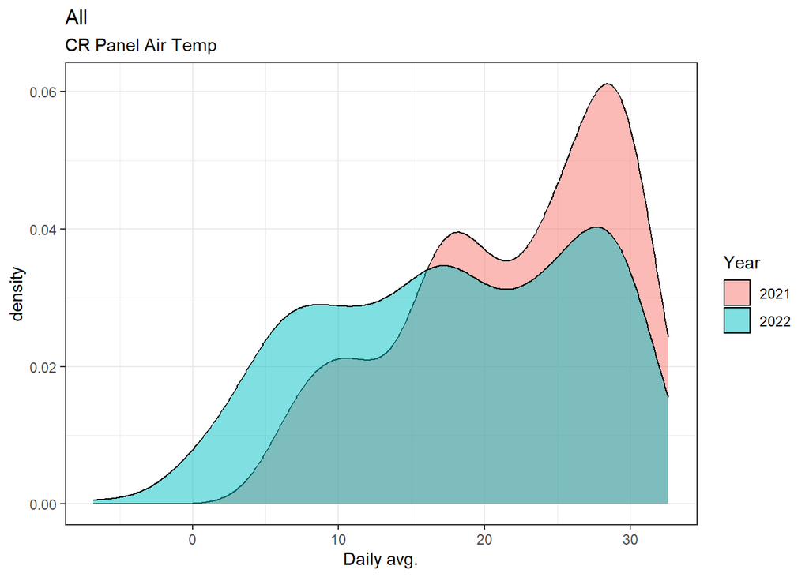

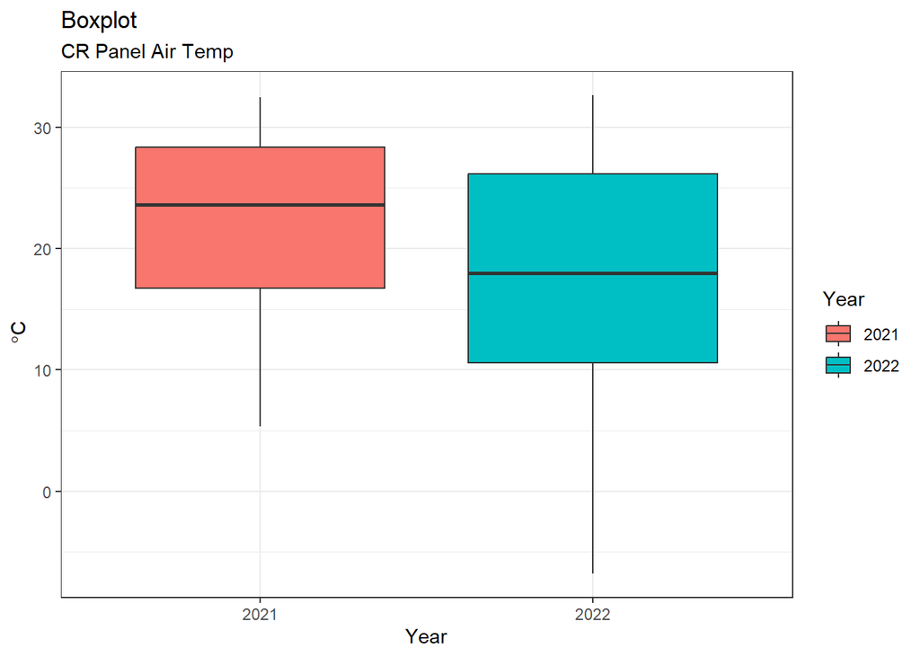

### PAR

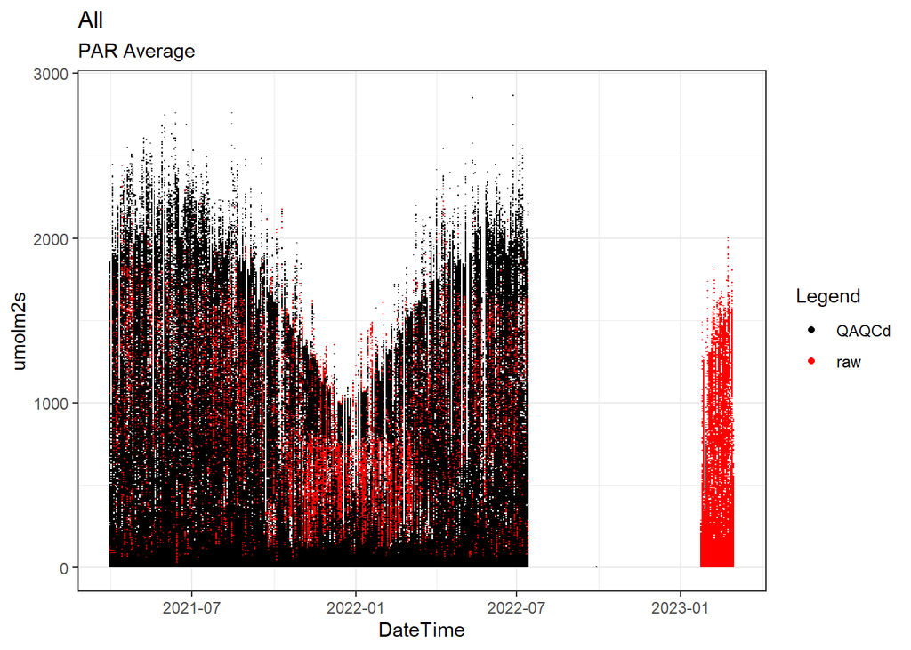

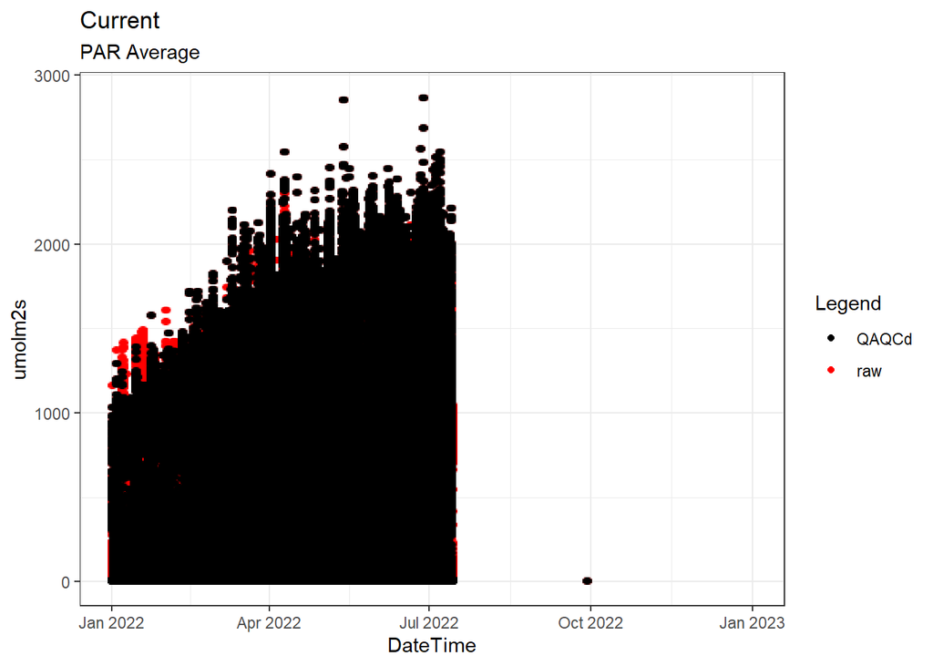

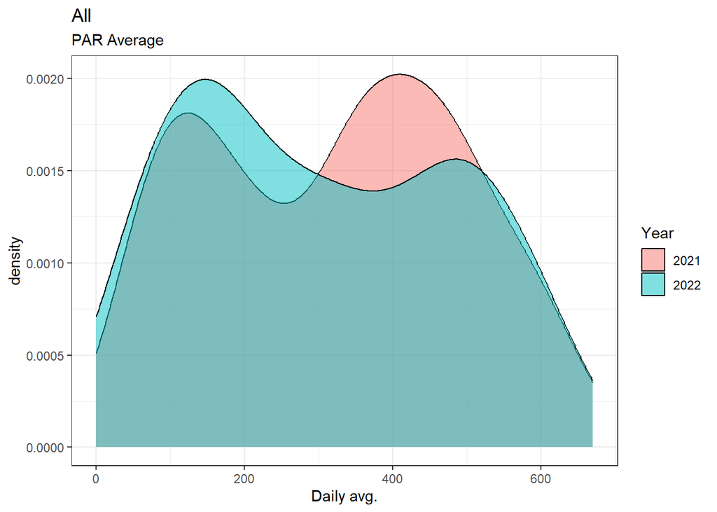

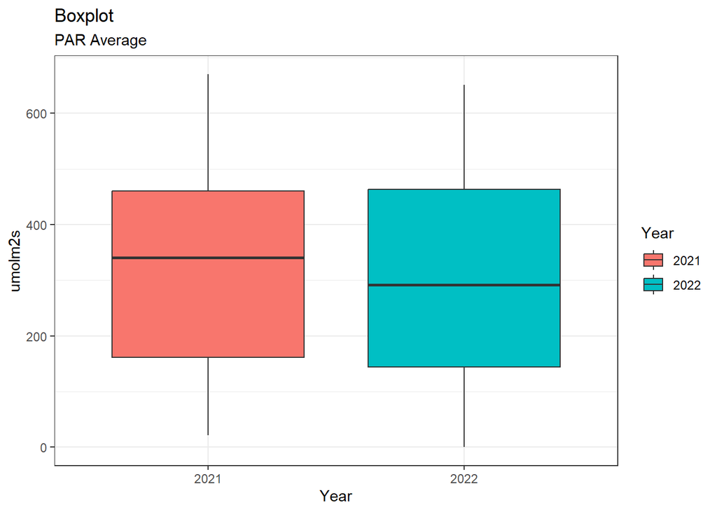

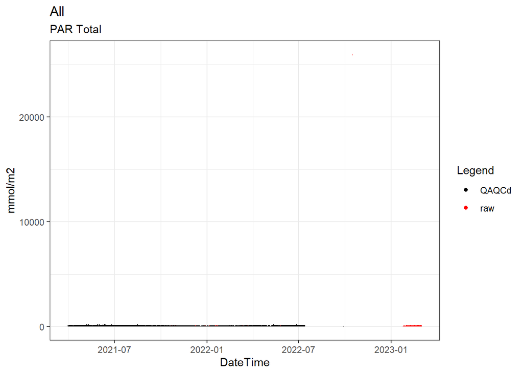

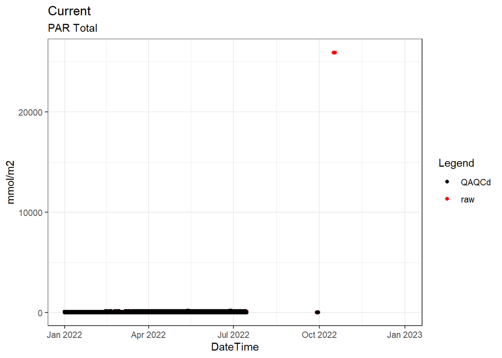

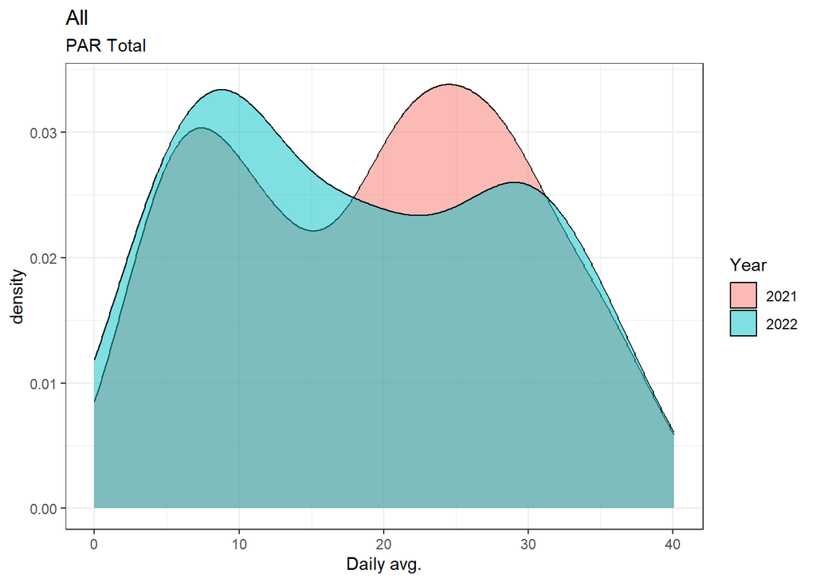

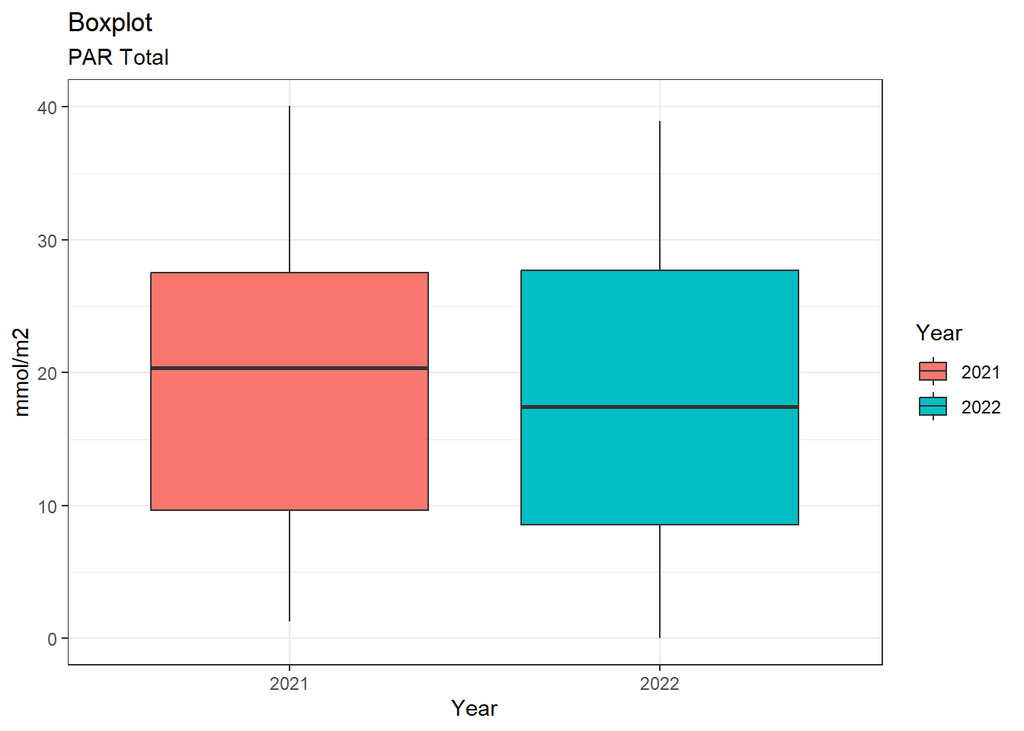

### Barometric Pressure

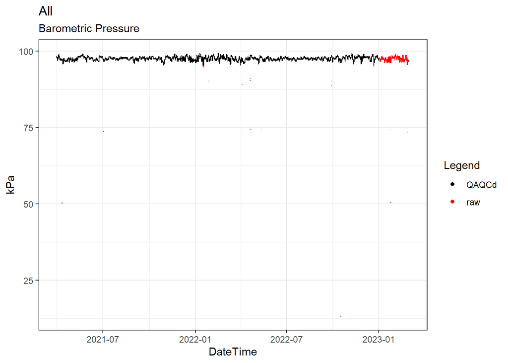

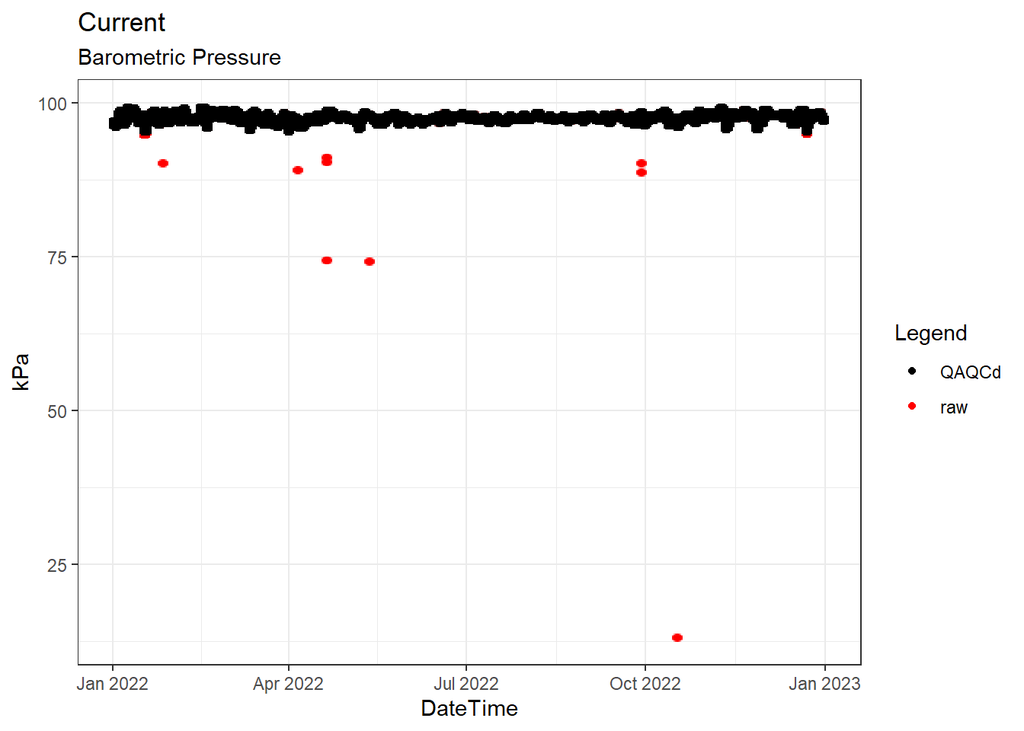

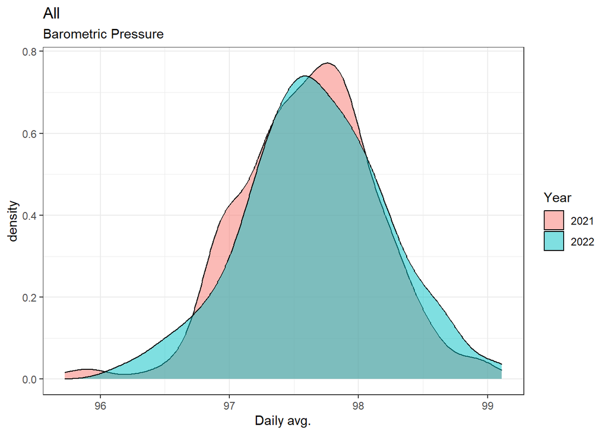

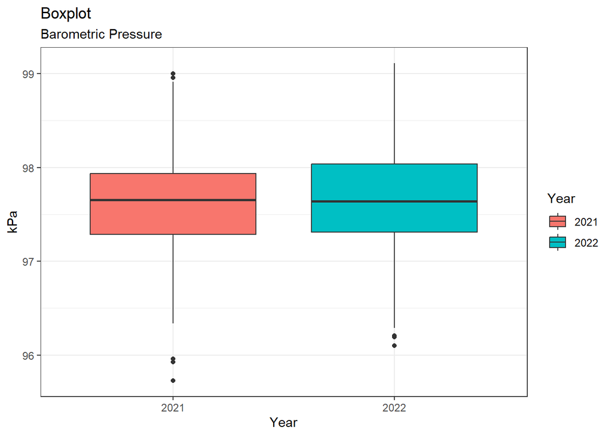

### Relative Humidity

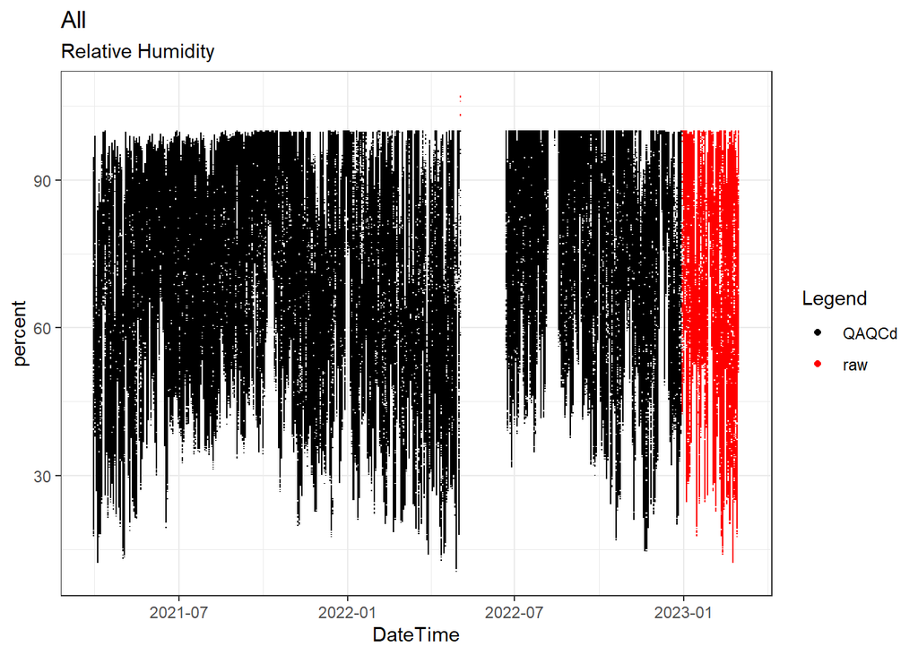

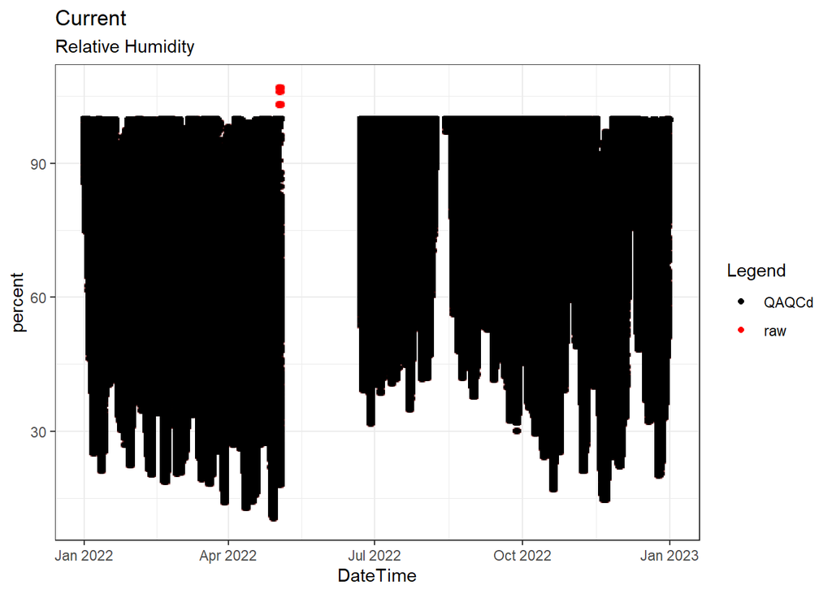

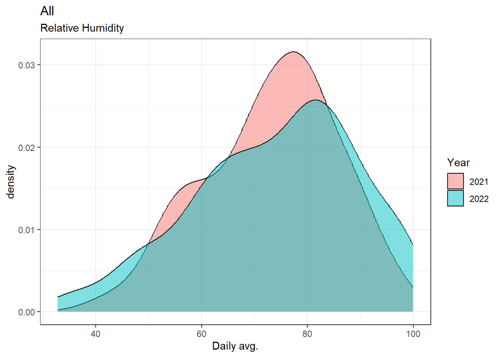

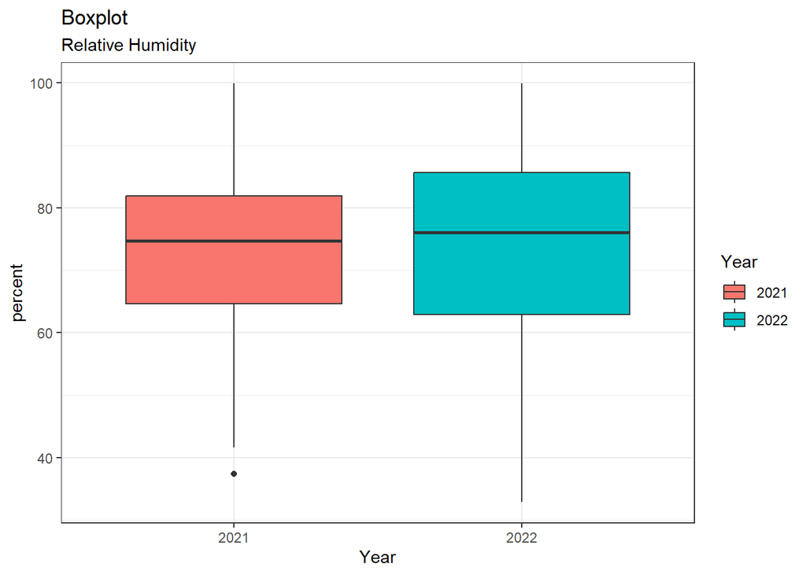

### Rain Total

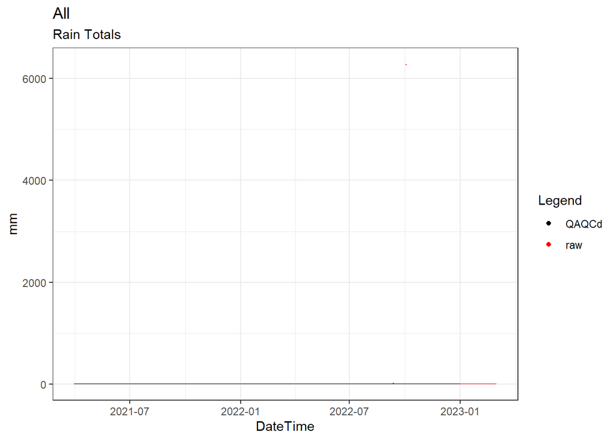

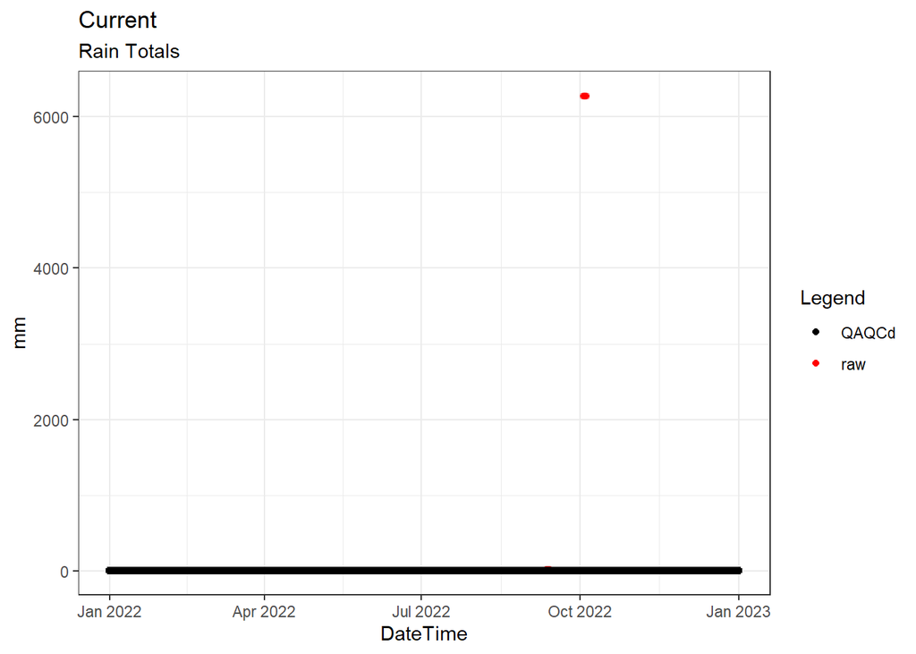

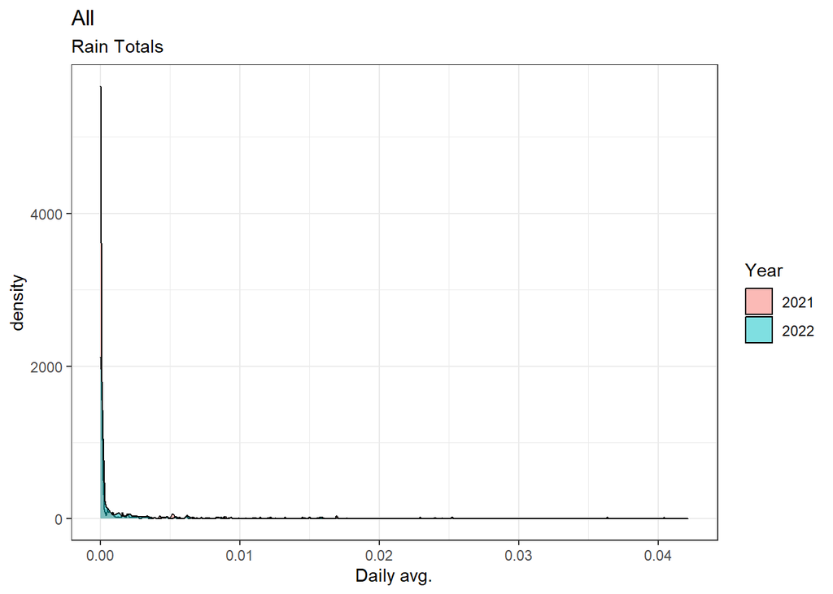

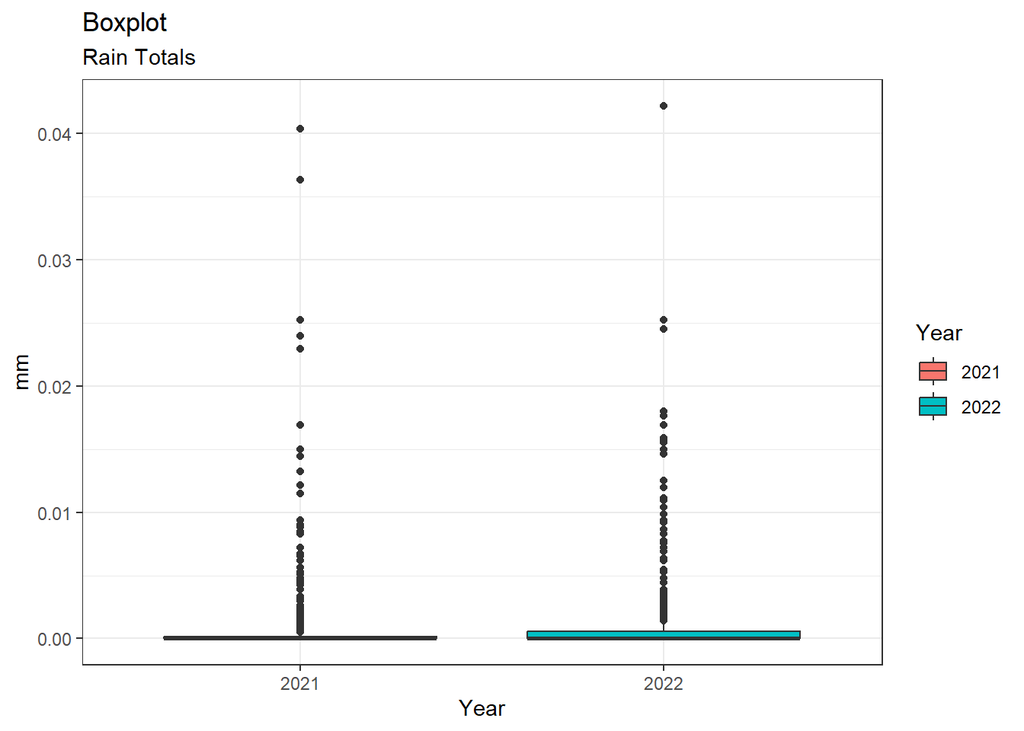